# findings

#### Analysis for the United States

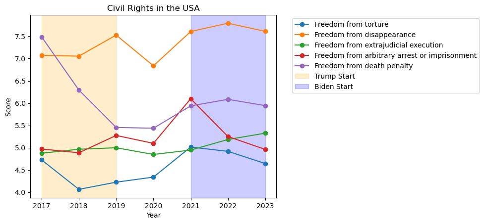

```python
df_usa = df[df['country'] == 'United States']
cols = df_usa.columns[2:]

df_usa = df_usa.set_index('year')
ax = df_usa[cols].plot(marker='o')
plt.title('Civil Rights in the USA')
plt.xlabel('Year')
plt.ylabel('Score')
plt.legend(title='Indicator', bbox_to_anchor=(1.05, 1), loc='upper left')

# Shade 2017-2018 (Trump start) and 2021-2022 (Biden start)
plt.axvspan(2017, 2019, color='orange', alpha=0.2, label='Trump Start')
plt.axvspan(2021, 2023, color='blue', alpha=0.2, label='Biden Start')

handles, labels = ax.get_legend_handles_labels()
by_label = OrderedDict(zip(labels, handles))
plt.legend(by_label.values(), by_label.keys(), bbox_to_anchor=(1.05, 1), loc='upper left')
plt.show()
```

This show most indicators holding steady overtime in the united states. However, we see that freedom for death peanlty significantly declines during the trump admin and then rebounds following the election of Joe Biden. This is in line with politcial belifs held by trump and biden.

### Economic Prosperity

```python
civil_poli_rights = pd.read_csv('./cpr.csv')
global_best = pd.read_csv('./esr_hiy_globalbest.csv')

col_map = {
    "HiY_Education_All_GBScore": "Education Score",
    "HiY_Health_All_GBScore": "Health Score",
    "HiY_QofL_All_GBScore": "Quality of Life Score",
    "HiY_Work_All_GBScore": "Work Score",
    "HiY_Food_All_GBScore": "Food Security Score",
    "HiY_Housing_All_GBScore": "Housing Score",
    "TotNetUpSecEn_All_GBScore": "Secondary Enrollment Score",
    "PISAmath_All_GBScore": "Math Proficiency",
    "PISAreading_All_GBScore": "Reading Proficiency",
    "PISAscience_All_GBScore": "Science Proficiency",
    "HiY_PISAAverage_All_GBScore": "Average PISA Score",
    "FoodSecure_All_GBScore": "Food Secure Score",
    "SeniorSurvival_All_GBScore": "Senior Survival Score",
    "U5Survival_All_GBScore": "Child Survival Score",
    "NotRelPoor_GBScore": "Not in Relative Poverty",
    "NotLTUnemploy_All_GBScore": "Not Long-Term Unemployed",
    "NotLowBirWt_GBScore": "Normal Birth Weight Rate",
    "SafeSanitation_GBScore": "Safe Sanitation Score",
}

# Rename columns in global_best using col_map
global_best_renamed = global_best.rename(columns=col_map)

# select relevant columns
df = global_best_renamed[list(col_map.values()) + ['Country', 'Year']]

df_yearly_mean = df.groupby('Year').mean(numeric_only=True)
```

```python
df.isnull().mean().sort_values(ascending=False)
```

```
Quality of Life Score         0.972973
Housing Score                 0.921593
Food Secure Score             0.876126
Food Security Score           0.876126
Education Score               0.870777
Science Proficiency           0.853181
Average PISA Score            0.853181
Work Score                    0.851351
Math Proficiency              0.822354
Not Long-Term Unemployed      0.816019
Reading Proficiency           0.811937
Not in Relative Poverty       0.796312
Health Score                  0.652168
Normal Birth Weight Rate      0.652168
Safe Sanitation Score         0.607264
Secondary Enrollment Score    0.517736
Child Survival Score          0.192990
Senior Survival Score         0.163288
Country                       0.000000
Year                          0.000000
dtype: float64
```

#### Trends Overtime

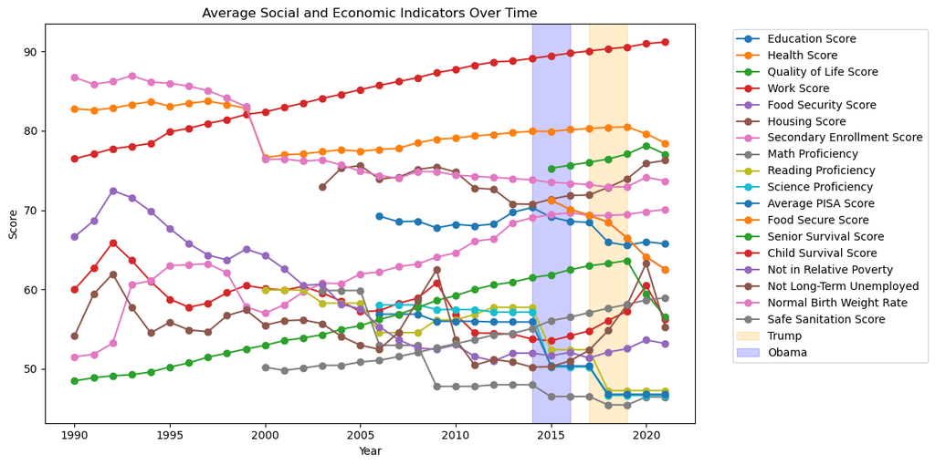

```python
from collections import OrderedDict

ax = df_yearly_mean.plot(marker='o', figsize=(12, 6))
plt.title('Average Social and Economic Indicators Over Time')
plt.xlabel('Year')
plt.ylabel('Score')
plt.legend(title='Indicator', bbox_to_anchor=(1.05, 1), loc='upper left')

# Highlight US presidential term transitions (optional)
plt.axvspan(2017, 2019, color='orange', alpha=0.2, label='Trump ')
plt.axvspan(2014, 2016, color='blue', alpha=0.2, label='Obama')

# Clean legend
handles, labels = ax.get_legend_handles_labels()
by_label = OrderedDict(zip(labels, handles))
plt.legend(by_label.values(), by_label.keys(), bbox_to_anchor=(1.05, 1), loc='upper left')

plt.tight_layout()
plt.show()
```

From this long-term graph, we see differing long-term trends of the indicators. Because of this, we should calculate a line of best fit of each indicator up until the beginning of the analysis window, to be able to better analyze the impact of Trump and Obama on the global indictors

```python
from sklearn.linear_model import LinearRegression

# Filter data up until 2017
df_pre_2017 = df_yearly_mean[df_yearly_mean.index <= 2017]

best_fit_lines = {}

for column in df_pre_2017.columns:
    data = df_pre_2017[[column]].dropna()

    if not data.empty:
        X = data.index.values.reshape(-1, 1)
        y = data[column].values

        model = LinearRegression()
        model.fit(X, y)

        best_fit_lines[column] = {
            'slope': model.coef_[0],
            'intercept': model.intercept_
        }
```

We have a lot of indicators, so we will separate the data into positive-trends and negative-trends for cleaner analysis.